# Overweight reasons

Kadir Yurdakul

2025-01-07

```r
library(tidyverse)
library(hrbrthemes)
library(viridis)
library(dplyr)
library(ggcorrplot)
library(corrplot)
library(ggplot2)
library(tidyr)
library(ggExtra)
library(reshape2)
library(gridExtra)
library(FSA)
```

```r
# data import in environment

#my_data <- read.csv(file = "C:/BTEC581/R project/dataset/ObesityDataSet_raw_and_data_sinthetic.csv")
my_data <- read.csv(file = "archive/ObesityDataSet_raw_and_data_sinthetic.csv")
```

# Data Discription

```r
head(my_data)
```

```
##   Gender Age Height Weight family_history_with_overweight FAVC FCVC NCP
## 1 Female  21   1.62   64.0                            yes   no    2   3
## 2 Female  21   1.52   56.0                            yes   no    3   3
## 3   Male  23   1.80   77.0                            yes   no    2   3
## 4   Male  27   1.80   87.0                             no   no    3   3
## 5   Male  22   1.78   89.8                             no   no    2   1
## 6   Male  29   1.62   53.0                             no  yes    2   3
##        CAEC SMOKE CH2O SCC FAF TUE       CALC                MTRANS
## 1 Sometimes    no    2  no   0   1         no Public_Transportation
## 2 Sometimes   yes    3 yes   3   0  Sometimes Public_Transportation
## 3 Sometimes    no    2  no   2   1 Frequently Public_Transportation
## 4 Sometimes    no    2  no   2   0 Frequently               Walking
## 5 Sometimes    no    2  no   0   0  Sometimes Public_Transportation
## 6 Sometimes    no    2  no   0   0  Sometimes            Automobile
##            NObeyesdad
## 1       Normal_Weight
## 2       Normal_Weight
## 3       Normal_Weight
## 4  Overweight_Level_I
## 5 Overweight_Level_II
## 6       Normal_Weight
```

```r
str(my_data)
```

```
## 'data.frame':    2111 obs. of  17 variables:
##  $ Gender                        : chr  "Female" "Female" "Male" "Male" ...
##  $ Age                           : num  21 21 23 27 22 29 23 22 24 22 ...
##  $ Height                        : num  1.62 1.52 1.8 1.8 1.78 1.62 1.5 1.64 1.78 1.72 ...
##  $ Weight                        : num  64 56 77 87 89.8 53 55 53 64 68 ...
##  $ family_history_with_overweight: chr  "yes" "yes" "yes" "no" ...
##  $ FAVC                          : chr  "no" "no" "no" "no" ...
##  $ FCVC                          : num  2 3 2 3 2 2 3 2 3 2 ...
##  $ NCP                           : num  3 3 3 3 1 3 3 3 3 3 ...
##  $ CAEC                          : chr  "Sometimes" "Sometimes" "Sometimes" "Sometimes" ...
##  $ SMOKE                         : chr  "no" "yes" "no" "no" ...
##  $ CH2O                          : num  2 3 2 2 2 2 2 2 2 2 ...
##  $ SCC                           : chr  "no" "yes" "no" "no" ...
##  $ FAF                           : num  0 3 2 2 0 0 1 3 1 1 ...
##  $ TUE                           : num  1 0 1 0 0 0 0 0 1 1 ...
##  $ CALC                          : chr  "no" "Sometimes" "Frequently" "Frequently" ...
##  $ MTRANS                        : chr  "Public_Transportation" "Public_Transportation" "Public_Transportation" "Walking" ...
##  $ NObeyesdad                    : chr  "Normal_Weight" "Normal_Weight" "Normal_Weight" "Overweight_Level_I" ...
```

```r
glimpse(my_data)
```

```
## Rows: 2,111
## Columns: 17
## $ Gender                         <chr> "Female", "Female", "Male", "Male", "Ma…
## $ Age                            <dbl> 21, 21, 23, 27, 22, 29, 23, 22, 24, 22,…
## $ Height                         <dbl> 1.62, 1.52, 1.80, 1.80, 1.78, 1.62, 1.5…
## $ Weight                         <dbl> 64.0, 56.0, 77.0, 87.0, 89.8, 53.0, 55.…
## $ family_history_with_overweight <chr> "yes", "yes", "yes", "no", "no", "no", …
## $ FAVC                           <chr> "no", "no", "no", "no", "no", "yes", "y…
## $ FCVC                           <dbl> 2, 3, 2, 3, 2, 2, 3, 2, 3, 2, 3, 2, 3, …
## $ NCP                            <dbl> 3, 3, 3, 3, 1, 3, 3, 3, 3, 3, 3, 3, 3, …
## $ CAEC                           <chr> "Sometimes", "Sometimes", "Sometimes", …
## $ SMOKE                          <chr> "no", "yes", "no", "no", "no", "no", "n…
## $ CH2O                           <dbl> 2, 3, 2, 2, 2, 2, 2, 2, 2, 2, 3, 2, 3, …
## $ SCC                            <chr> "no", "yes", "no", "no", "no", "no", "n…
## $ FAF                            <dbl> 0, 3, 2, 2, 0, 0, 1, 3, 1, 1, 2, 2, 2, …
## $ TUE                            <dbl> 1, 0, 1, 0, 0, 0, 0, 0, 1, 1, 2, 1, 0, …
## $ CALC                           <chr> "no", "Sometimes", "Frequently", "Frequ…
## $ MTRANS                         <chr> "Public_Transportation", "Public_Transp…
## $ NObeyesdad                     <chr> "Normal_Weight", "Normal_Weight", "Norm…
```

```r
dim(my_data)
```

```
## [1] 2111   17
```

```r
colnames(my_data)
```

```
##  [1] "Gender"                         "Age"
##  [3] "Height"                         "Weight"
##  [5] "family_history_with_overweight" "FAVC"
##  [7] "FCVC"                           "NCP"
##  [9] "CAEC"                           "SMOKE"
## [11] "CH2O"                           "SCC"
## [13] "FAF"                            "TUE"
## [15] "CALC"                           "MTRANS"
## [17] "NObeyesdad"
```

# DATA MANIPULATION

## Changing colum names and adding ID numbers for every data

```r
my_data$ID <- c(1:2111)
my_data <- my_data %>% select(ID,everything())
```

```r
colnames(my_data) <- c("ıd", "sex","age","height","weight","family_hist","high_cal_cons","vegetable_cons","main_meals","snacks","smoke","water_cons","cal_control","physically_act","screen_time","alcohol_cons","transporter", "obesity_type")
```

## adding bmi var

```r
my_data$bmi <- my_data$weight / (my_data$height^2)
```

Gender (sex), Age (sex), Height (height), Weight (weight), family history with overweight, frequent consumption of high caloric food (high_cal_cons), frequency of consumption of vegetables (vegetable_cons), number of main meals (main_meals), consumption of food between meals (snacks), smoking yes or no (smoke), consumption of water daily (water_cons), consumption of alcohol (alcohol_cons), calories consumption monitoring (cal_control), physical activity frequency (physically_act), time using technology devices (screen_time), transportation used (transporter), NObeyesdad (obesity_type)

## NA control

```r
sum(is.na(my_data))
```

```
## [1] 0
```

## Characterizations

```r
summary(my_data)
```

```
##        ıd             sex                 age            height
##  Min.   :   1.0   Length:2111        Min.   :14.00   Min.   :1.450
##  1st Qu.: 528.5   Class :character   1st Qu.:19.95   1st Qu.:1.630
##  Median :1056.0   Mode  :character   Median :22.78   Median :1.700
##  Mean   :1056.0                      Mean   :24.31   Mean   :1.702
##  3rd Qu.:1583.5                      3rd Qu.:26.00   3rd Qu.:1.768
##  Max.   :2111.0                      Max.   :61.00   Max.   :1.980
##      weight       family_hist        high_cal_cons      vegetable_cons
##  Min.   : 39.00   Length:2111        Length:2111        Min.   :1.000
##  1st Qu.: 65.47   Class :character   Class :character   1st Qu.:2.000
##  Median : 83.00   Mode  :character   Mode  :character   Median :2.386
##  Mean   : 86.59                                         Mean   :2.419
##  3rd Qu.:107.43                                         3rd Qu.:3.000
##  Max.   :173.00                                         Max.   :3.000
##    main_meals       snacks             smoke             water_cons
##  Min.   :1.000   Length:2111        Length:2111        Min.   :1.000
##  1st Qu.:2.659   Class :character   Class :character   1st Qu.:1.585
##  Median :3.000   Mode  :character   Mode  :character   Median :2.000
##  Mean   :2.686                                         Mean   :2.008
##  3rd Qu.:3.000                                         3rd Qu.:2.477
##  Max.   :4.000                                         Max.   :3.000
##  cal_control        physically_act    screen_time     alcohol_cons
##  Length:2111        Min.   :0.0000   Min.   :0.0000   Length:2111
##  Class :character   1st Qu.:0.1245   1st Qu.:0.0000   Class :character
##  Mode  :character   Median :1.0000   Median :0.6253   Mode  :character
##                     Mean   :1.0103   Mean   :0.6579
##                     3rd Qu.:1.6667   3rd Qu.:1.0000
##                     Max.   :3.0000   Max.   :2.0000
##  transporter        obesity_type            bmi
##  Length:2111        Length:2111        Min.   :13.00
##  Class :character   Class :character   1st Qu.:24.33
##  Mode  :character   Mode  :character   Median :28.72
##                                        Mean   :29.70
##                                        3rd Qu.:36.02
##                                        Max.   :50.81
```

# Hypothesis-1: Genetic background is important for being overweight

## Aim 1: FEMALE MORE TEND TO BEING OBESITY

```r
my_data %>% select(sex,obesity_type) %>% head()
```

```
##      sex        obesity_type
## 1 Female       Normal_Weight
## 2 Female       Normal_Weight
## 3   Male       Normal_Weight
## 4   Male  Overweight_Level_I
## 5   Male Overweight_Level_II
## 6   Male       Normal_Weight
```

```r
table(
  my_data$sex,my_data$obesity_type
)
```

```
##
##          Insufficient_Weight Normal_Weight Obesity_Type_I Obesity_Type_II
##   Female                 173           141            156               2
##   Male                    99           146            195             295
##
##          Obesity_Type_III Overweight_Level_I Overweight_Level_II
##   Female              323                145                 103
##   Male                  1                145                 187
```

### Chi-Square Test for Independence

```r
chisq.test(table(my_data$sex, my_data$obesity_type))
```

```
##
##  Pearson's Chi-squared test
##
## data:  table(my_data$sex, my_data$obesity_type)
## X-squared = 657.75, df = 6, p-value < 2.2e-16
```

Since p-value < 0.05, H0 hypothesis is rejected. That is, there is a statistically significant relationship between gender and obesity type.

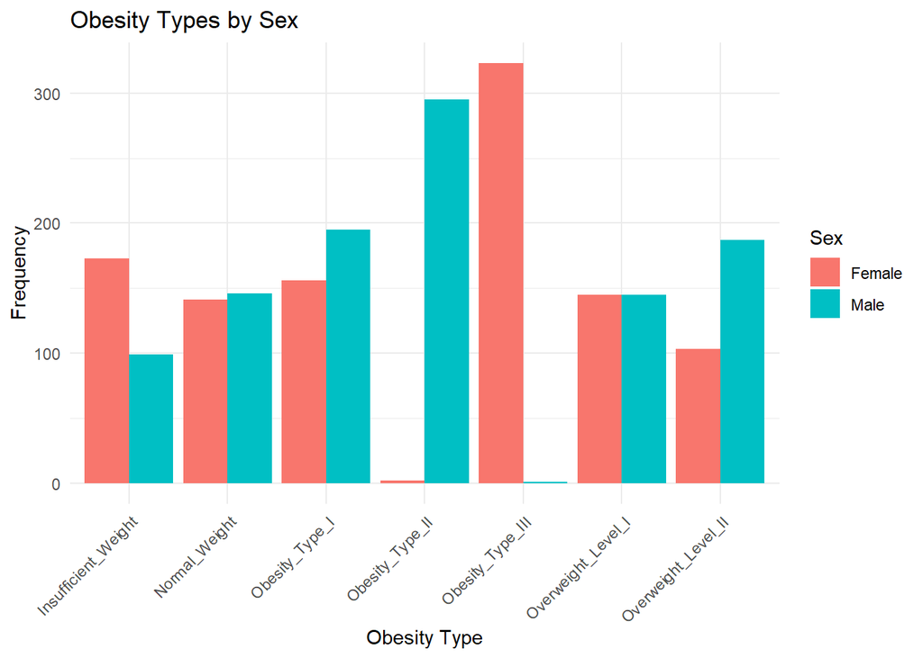

```r
ggplot(my_data, aes(x = obesity_type, fill = sex)) +
  geom_bar(position = "dodge") +
  theme_minimal() +
  labs(
    title = "Obesity Types by Sex",
    x = "Obesity Type",
    y = "Frequency",
    fill = "Sex"
  ) +
  theme(axis.text.x = element_text(angle = 45, hjust = 1))
```

According to Pearson’s Chi-Square Test results, there is a significant relationship between sex and obesity type (obesity_type) (X-squared = 657.75, df = 6, p-value < 2.2e-16).

Because the p-value (< 0.05) is quite small and this shows that the two variables are not independent, that is, there is a statistically significant relationship between them.

### analyze for bmi and weight by sex

```r
my_data %>% select(sex,bmi) %>% head()
```

```
##      sex      bmi
## 1 Female 24.38653
## 2 Female 24.23823
## 3   Male 23.76543
## 4   Male 26.85185
## 5   Male 28.34238
## 6   Male 20.19509
```

```r
shapiro.test(my_data$bmi); shapiro.test(my_data$weight)
```

```
##
##  Shapiro-Wilk normality test
##
## data:  my_data$bmi
## W = 0.97475, p-value < 2.2e-16
```

```
##
##  Shapiro-Wilk normality test
##
## data:  my_data$weight
## W = 0.9765, p-value < 2.2e-16
```

For BMI (Body Mass Index) data: Since the p-value is too small (p < 0.05), the BMI data does not follow a normal distribution. For Weight data: Similarly, since the p-value is too small (p < 0.05), the Weight data does not follow a normal distribution.

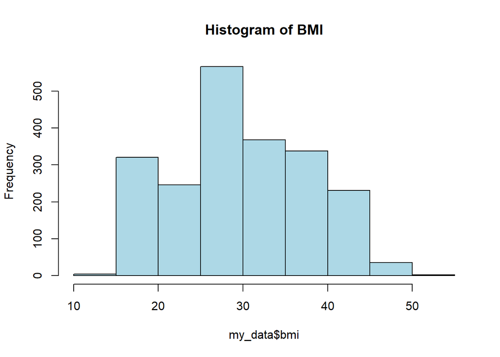

```r
hist(my_data$bmi, main = "Histogram of BMI", col = "lightblue")
```

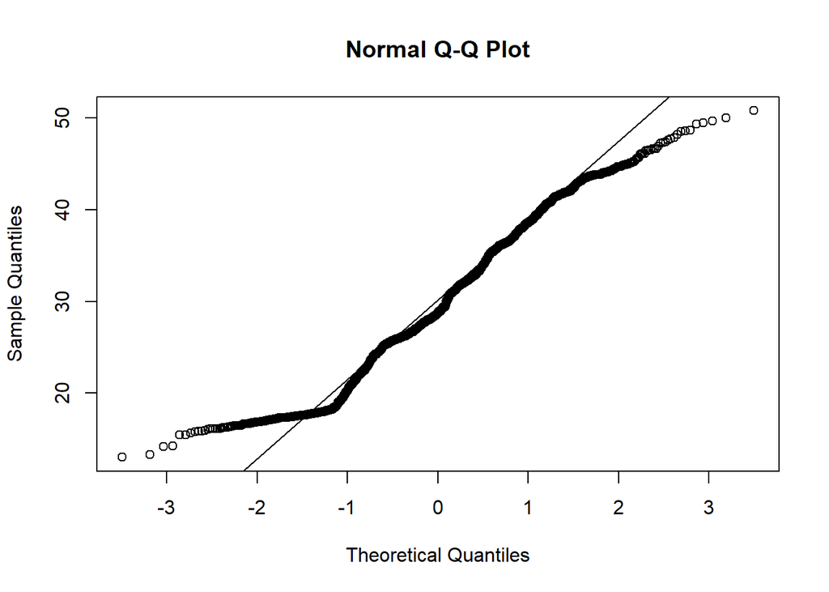

```r
qqnorm(my_data$bmi); qqline(my_data$bmi)
```

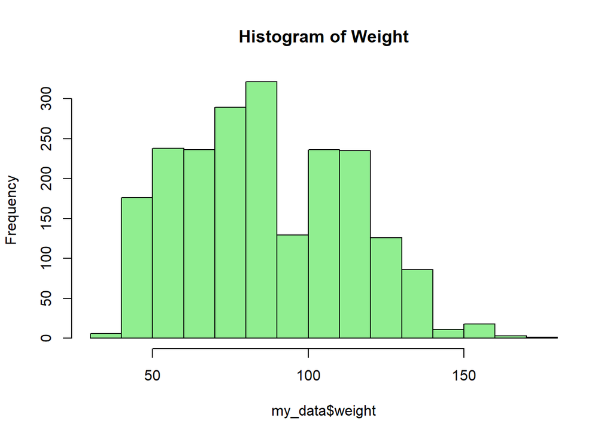

```r
hist(my_data$weight, main = "Histogram of Weight", col = "lightgreen")
```

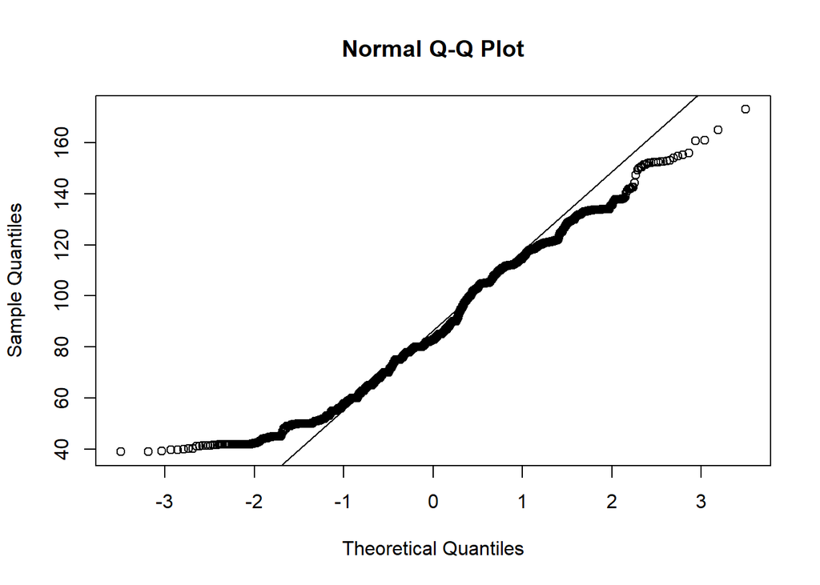

```r
qqnorm(my_data$weight); qqline(my_data$weight)
```

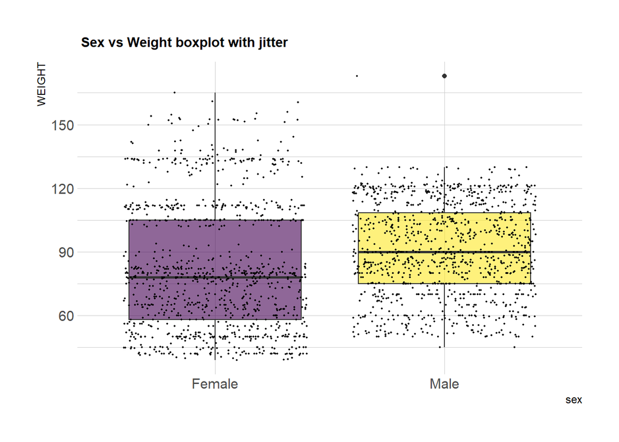

```r
my_data %>% ggplot( aes(sex, weight, fill = sex)) +
  geom_boxplot() +
  scale_fill_viridis(discrete = TRUE, alpha=0.6) +
    geom_jitter(color="black", size=0.4, alpha=0.9) +
    theme_ipsum() +
    theme(
      legend.position="none",
      plot.title = element_text(size=11)
    ) +
    ggtitle(" Sex vs Weight boxplot with jitter") +
    ylab("WEIGHT")
```

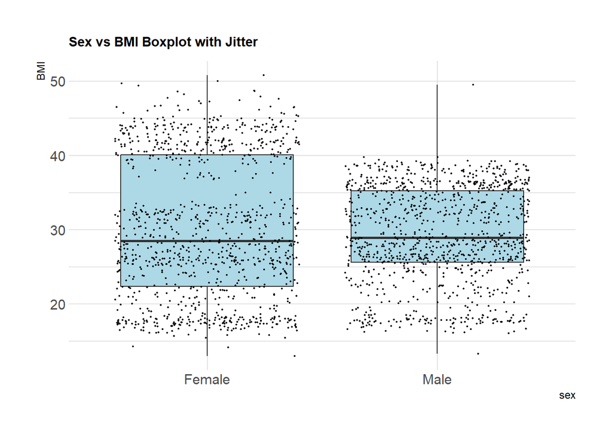

```r
my_data %>%
  ggplot(aes(sex, bmi)) +
  geom_boxplot(fill = "lightblue") +
  geom_jitter(color = "black", size = 0.4, alpha = 0.9) +
  theme_ipsum() +
  theme(
    legend.position = "none",
    plot.title = element_text(size = 11)
  ) +
  ggtitle("Sex vs BMI Boxplot with Jitter") +
  ylab("BMI")
```

### wilcox tests

```r
wilcox.test(weight ~ sex, data = my_data)
```

```
##
##  Wilcoxon rank sum test with continuity correction
##
## data:  weight by sex
## W = 425391, p-value < 2.2e-16
## alternative hypothesis: true location shift is not equal to 0
```

p-value < 2.2e-16: The p-value is very small, indicating a significant difference between the groups. Typically, a p-value of less than 0.05 is considered to indicate a difference between the two groups.

```r
 wilcox.test(bmi ~ sex, data = my_data)
```

```
##
##  Wilcoxon rank sum test with continuity correction
##
## data:  bmi by sex
## W = 568467, p-value = 0.4113
## alternative hypothesis: true location shift is not equal to 0
```

The p-value of this test is 0.4113, which indicates that there is no statistically significant difference in the BMI distributions between men and women.

Alternative Hypothesis: The alternative hypothesis of this test is that there is a difference between the groups, but since the p-value is large, this hypothesis is rejected and the group centers are assumed to be equal.

## Aim 2 : IF THERE İS OBESITY HISTORY IN FAMILY, THE PERSON TEND TO BE GAIN WEIGHT

```r
table(my_data$family_hist, my_data$obesity_type)
```

```
##
##       Insufficient_Weight Normal_Weight Obesity_Type_I Obesity_Type_II
##   no                  146           132              7               1
##   yes                 126           155            344             296
##
##       Obesity_Type_III Overweight_Level_I Overweight_Level_II
##   no                 0                 81                  18
##   yes              324                209                 272
```

```r
table(my_data$family_hist)
```

```
##
##   no  yes
##  385 1726
```

```r
chisq.test(table(my_data$family_hist, my_data$obesity_type))
```

```
##
##  Pearson's Chi-squared test
##
## data:  table(my_data$family_hist, my_data$obesity_type)
## X-squared = 621.98, df = 6, p-value < 2.2e-16
```

p-value (p-value < 2.2e-16): The p-value is extremely small (nearly zero). This leads us to reject the null hypothesis. The null hypothesis is a claim that there is no significant difference between family_hist (family history of obesity) and obesity_type (obesity type). The p-value here indicates that this difference is highly significant and that there is a significant relationship between the groups.

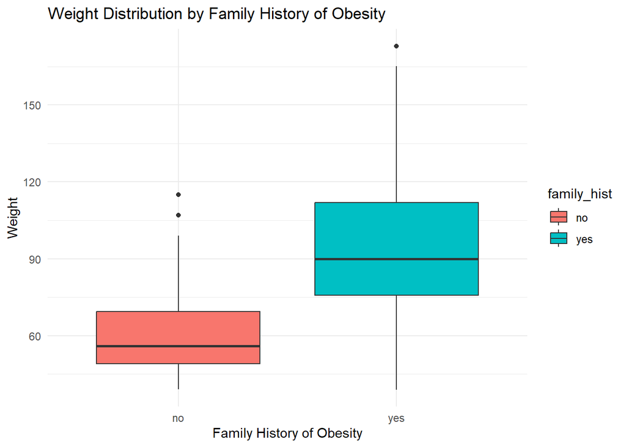

```r
my_data %>% ggplot( aes(family_hist, weight, fill = family_hist))+
  geom_boxplot() +
  labs(title = "Weight Distribution by Family History of Obesity",
       x = "Family History of Obesity", y = "Weight") +
  theme_minimal()
```

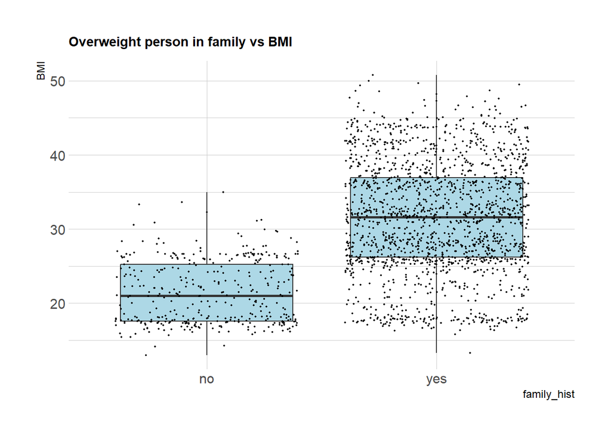

```r
my_data %>%
  ggplot(aes(family_hist, bmi)) +
  geom_boxplot(fill = "lightblue") +
  geom_jitter(color = "black", size = 0.4, alpha = 0.9) +
  theme_ipsum() +
  theme(
    legend.position = "none",
    plot.title = element_text(size = 11)
  ) +
  ggtitle("Overweight person in family vs BMI ") +
  ylab("BMI")
```

### wilcox tests

```r
wilcox.test(weight ~ family_hist, data = my_data)
```

```
##
##  Wilcoxon rank sum test with continuity correction
##
## data:  weight by family_hist
## W = 79152, p-value < 2.2e-16
## alternative hypothesis: true location shift is not equal to 0
```

The p-value of this test shows that there is a statistically significant difference between the groups with and without family history (family_hist). That is, there is a significant difference in the weight distributions between those with family history and those without family history.

Alternative Hypothesis: The alternative hypothesis of this test is that there is a difference between the groups and since the p-value is very small, the alternative hypothesis is accepted.

```r
 wilcox.test(bmi ~ family_hist, data = my_data)
```

```
##
##  Wilcoxon rank sum test with continuity correction
##
## data:  bmi by family_hist
## W = 84700, p-value < 2.2e-16
## alternative hypothesis: true location shift is not equal to 0
```

The p-value of this test shows that there is a statistically significant difference between the groups with and without family history (family_hist). That is, there is a significant difference in the BMI distributions between those with and without family history.

Alternative Hypothesis: The alternative hypothesis of this test is that there is a difference between the groups and since the p-value is very small, the alternative hypothesis is accepted.

# Hypothesis-2:TRANSPORTER USAGE EFFECT ON OBESITY

## Aim 1:

```r
my_data %>% select(weight,bmi, obesity_type, transporter) %>% head(120)
```

```
##     weight      bmi        obesity_type           transporter
## 1     64.0 24.38653       Normal_Weight Public_Transportation
## 2     56.0 24.23823       Normal_Weight Public_Transportation
## 3     77.0 23.76543       Normal_Weight Public_Transportation
## 4     87.0 26.85185  Overweight_Level_I               Walking
## 5     89.8 28.34238 Overweight_Level_II Public_Transportation
## 6     53.0 20.19509       Normal_Weight            Automobile
## 7     55.0 24.44444       Normal_Weight             Motorbike
## 8     53.0 19.70553       Normal_Weight Public_Transportation
## 9     64.0 20.19947       Normal_Weight Public_Transportation
## 10    68.0 22.98540       Normal_Weight Public_Transportation
## 11   105.0 30.67933      Obesity_Type_I Public_Transportation
## 12    80.0 27.04164 Overweight_Level_II Public_Transportation
## 13    56.0 20.56933       Normal_Weight Public_Transportation
## 14    99.0 30.55556      Obesity_Type_I            Automobile
```

[output cut: 106 more lines]

```r
summary(my_data %>% select(weight,bmi, obesity_type, transporter))
```

```
##      weight            bmi        obesity_type       transporter
##  Min.   : 39.00   Min.   :13.00   Length:2111        Length:2111
##  1st Qu.: 65.47   1st Qu.:24.33   Class :character   Class :character
##  Median : 83.00   Median :28.72   Mode  :character   Mode  :character
##  Mean   : 86.59   Mean   :29.70
##  3rd Qu.:107.43   3rd Qu.:36.02
##  Max.   :173.00   Max.   :50.81
```

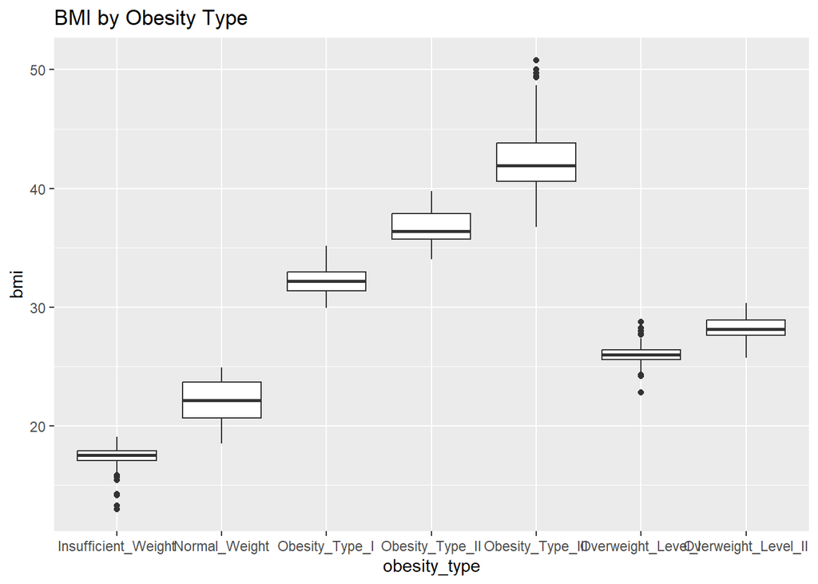

```r
ggplot(my_data, aes(x = obesity_type, y = bmi)) +
  geom_boxplot() +
  ggtitle("BMI by Obesity Type")
```

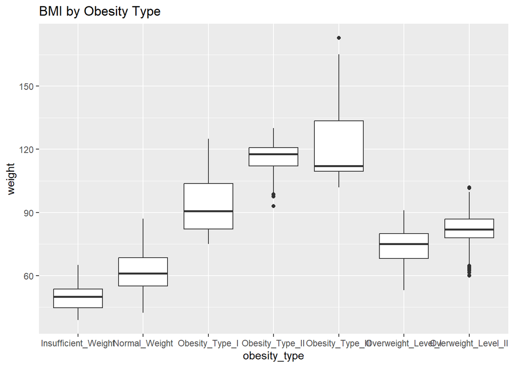

```r
ggplot(my_data, aes(x = obesity_type, y = weight)) +
  geom_boxplot() +
  ggtitle("BMI by Obesity Type")
```

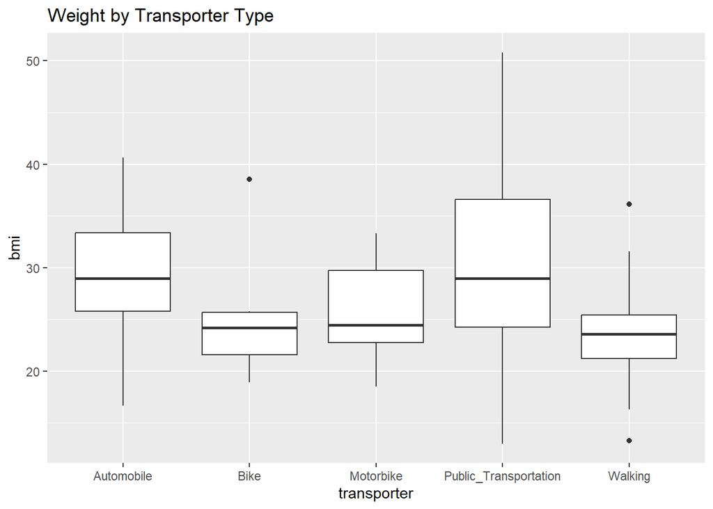

```r
ggplot(my_data, aes(x = transporter, y = bmi)) +
  geom_boxplot() +
  ggtitle("Weight by Transporter Type")
```

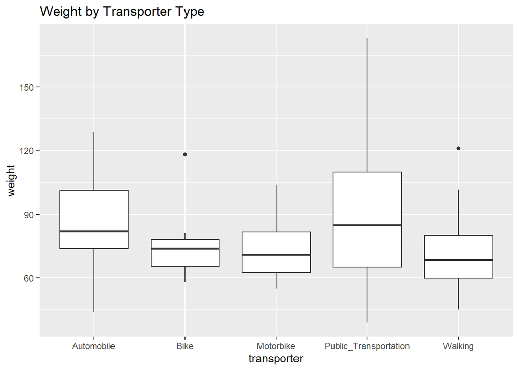

```r
ggplot(my_data, aes(x = transporter, y = weight)) +
  geom_boxplot() +
  ggtitle("Weight by Transporter Type")
```

```r
table(my_data$obesity_type, my_data$transporter)
```

```
##
##                       Automobile Bike Motorbike Public_Transportation Walking
##   Insufficient_Weight         46    0         0                   220       6
##   Normal_Weight               45    4         6                   200      32
##   Obesity_Type_I             110    0         3                   236       2
##   Obesity_Type_II             95    1         0                   200       1
##   Obesity_Type_III             1    0         0                   323       0
##   Overweight_Level_I          66    2         1                   212       9
##   Overweight_Level_II         94    0         1                   189       6
```

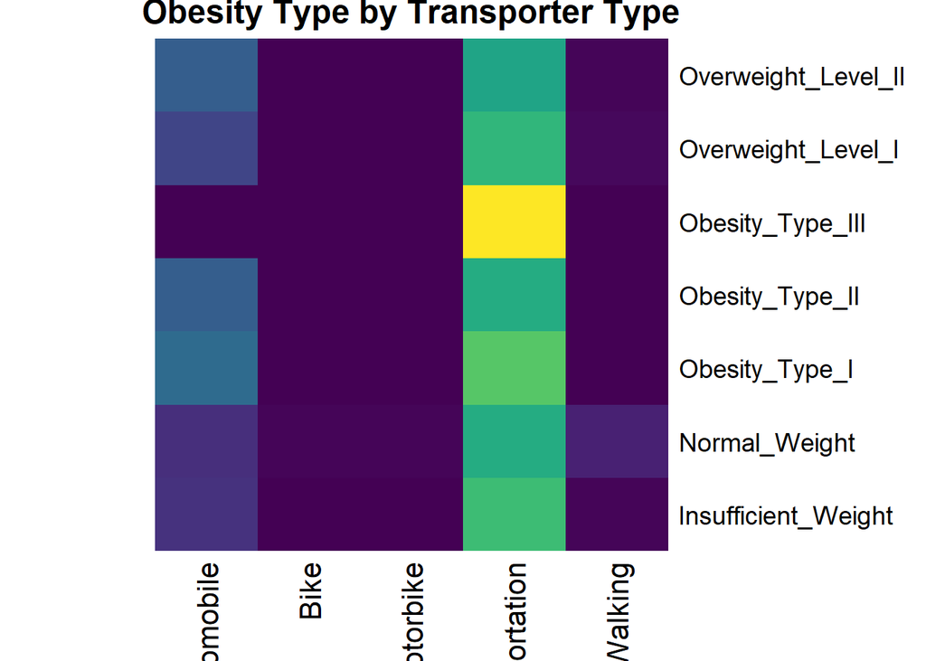

```r
heatmap(table(my_data$obesity_type, my_data$transporter),
        Colv = NA, Rowv = NA,
        col = viridis(100),
        scale = "none",
        main = "Obesity Type by Transporter Type")
```

```r
chisq.test(table(my_data$obesity_type, my_data$transporter))
```

```
##
##  Pearson's Chi-squared test
##
## data:  table(my_data$obesity_type, my_data$transporter)
## X-squared = 292.59, df = 24, p-value < 2.2e-16
```

Conclusion: Since the P-value is very small, it is concluded that there is a statistically significant relationship between the type of obesity and the type of transportation. In other words, there is a significant relationship between the types of obesity and the types of transportation (e.g. car, motorcycle, walking, etc.).

Alternative Hypothesis: The alternative hypothesis of the Chi-square test is that there is a relationship between the groups. Since the P-value is very small, the alternative hypothesis is accepted.

```r
kruskal.test(weight ~ transporter, data = my_data)
```

```
##
##  Kruskal-Wallis rank sum test
##
## data:  weight by transporter
## Kruskal-Wallis chi-squared = 27.531, df = 4, p-value = 1.552e-05
```

Since the p-value (0.00001552) is very small, we reject the null hypothesis in this case. The null hypothesis states that there is no difference between the groups. That is, there is a significant difference in weight between the transport types.

```r
kruskal.test(bmi ~ transporter, data = my_data)
```

```
##
##  Kruskal-Wallis rank sum test
##
## data:  bmi by transporter
## Kruskal-Wallis chi-squared = 46.479, df = 4, p-value = 1.958e-09
```

Since the p-value (0.00000000196) is very small, we reject the null hypothesis in this case. The null hypothesis states that there is no difference between the groups. As a result, there is a significant difference between the types of transportation and BMI.

### post-hoc test

```r
my_data$transporter <- factor(my_data$transporter)

dunnTest(weight ~ transporter, data = my_data)
```

```
## Dunn (1964) Kruskal-Wallis multiple comparison
```

```
##   p-values adjusted with the Holm method.
```

```
##                            Comparison          Z      P.unadj        P.adj
## 1                   Automobile - Bike  1.1055736 2.689111e-01 1.000000e+00
## 2              Automobile - Motorbike  1.7468708 8.065976e-02 5.646183e-01
## 3                    Bike - Motorbike  0.2315373 8.168974e-01 8.168974e-01
## 4  Automobile - Public_Transportation -0.4323782 6.654665e-01 1.000000e+00
## 5        Bike - Public_Transportation -1.1721755 2.411266e-01 1.000000e+00
## 6   Motorbike - Public_Transportation -1.8375513 6.612855e-02 5.290284e-01
## 7                Automobile - Walking  4.4632013 8.074415e-06 7.266973e-05
## 8                      Bike - Walking  0.5259551 5.989194e-01 1.000000e+00
## 9                 Motorbike - Walking  0.2998942 7.642578e-01 1.000000e+00
## 10    Public_Transportation - Walking  4.8160105 1.464568e-06 1.464568e-05
```

```r
test_res <- dunnTest(weight ~ transporter, data = my_data)
test_res <- test_res$res
test_res %>% filter(P.adj < 0.05)
```

```
##                        Comparison        Z      P.unadj        P.adj
## 1            Automobile - Walking 4.463201 8.074415e-06 7.266973e-05
## 2 Public_Transportation - Walking 4.816011 1.464568e-06 1.464568e-05
```

```r
dunnTest(bmi ~ transporter, data = my_data)
```

```
## Dunn (1964) Kruskal-Wallis multiple comparison
```

```
##   p-values adjusted with the Holm method.
```

```
##                            Comparison          Z      P.unadj        P.adj
## 1                   Automobile - Bike  1.6248568 1.041931e-01 6.251585e-01
## 2              Automobile - Motorbike  1.5922303 1.113330e-01 5.566648e-01
## 3                    Bike - Motorbike -0.2750912 7.832462e-01 7.832462e-01
## 4  Automobile - Public_Transportation -1.2007628 2.298432e-01 9.193729e-01
## 5        Bike - Public_Transportation -1.8020052 7.154459e-02 5.008121e-01
## 6   Motorbike - Public_Transportation -1.8164920 6.929494e-02 5.543595e-01
## 7                Automobile - Walking  5.6466710 1.635845e-08 1.472260e-07
## 8                      Bike - Walking  0.4505966 6.522803e-01 1.000000e+00
## 9                 Motorbike - Walking  0.9510249 3.415918e-01 1.000000e+00
## 10    Public_Transportation - Walking  6.3483848 2.175873e-10 2.175873e-09
```

```r
test_res <- dunnTest(bmi ~ transporter, data = my_data)
test_res <- test_res$res
test_res %>% filter(P.adj < 0.05)
```

```
##                        Comparison        Z      P.unadj        P.adj
## 1            Automobile - Walking 5.646671 1.635845e-08 1.472260e-07
## 2 Public_Transportation - Walking 6.348385 2.175873e-10 2.175873e-09
```

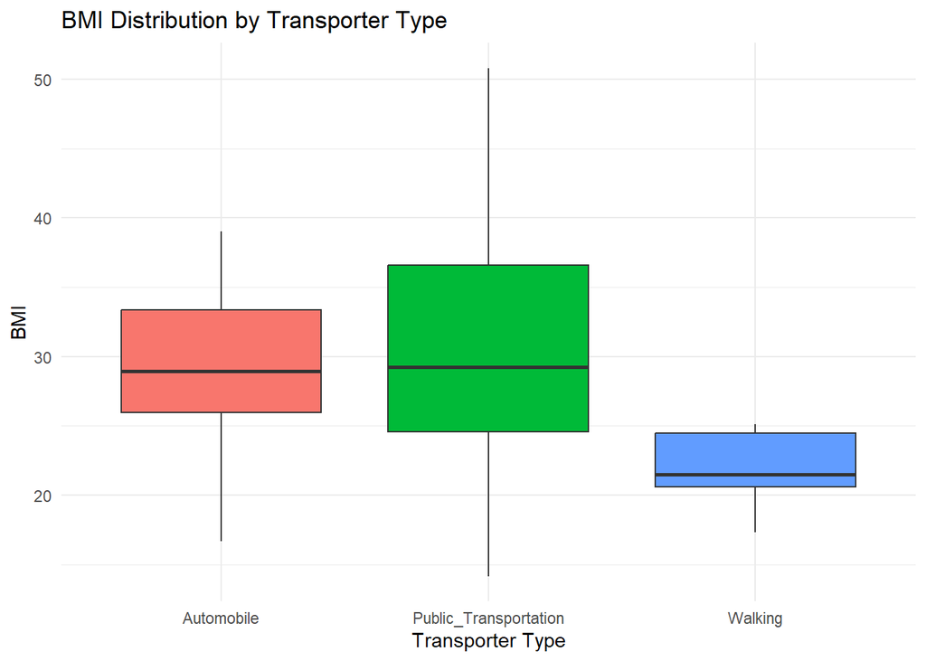

```r
ggplot(my_data %>% filter(transporter == c("Automobile","Walking","Public_Transportation")), aes(x = transporter, y = bmi, fill = transporter)) +
  geom_boxplot() +
  labs(title = "BMI Distribution by Transporter Type",
       x = "Transporter Type",
       y = "BMI") +
  theme_minimal() +
  theme(legend.position = "none")
```

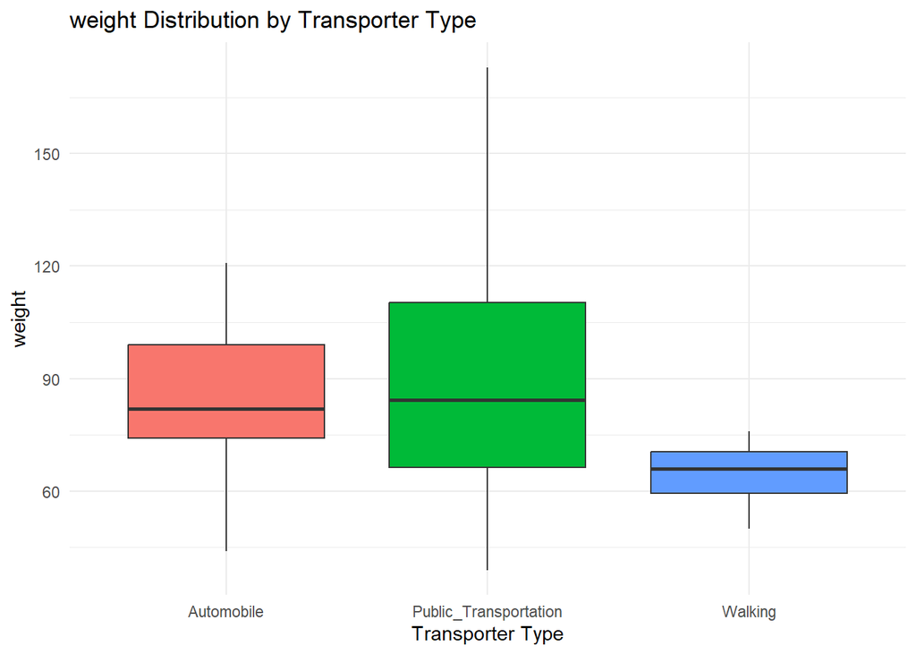

```r
ggplot(my_data %>% filter(transporter == c("Automobile","Walking","Public_Transportation")), aes(x = transporter, y = weight, fill = transporter)) +
  geom_boxplot() +
  labs(title = "weight Distribution by Transporter Type",
       x = "Transporter Type",
       y = "weight") +
  theme_minimal() +
  theme(legend.position = "none")
```

# Hypothesis-3:There is direct proportion between lifestyle and being overweight

```r
h2_my_data <- my_data %>% select(obesity_type, alcohol_cons, water_cons,smoke, snacks, main_meals, vegetable_cons, high_cal_cons, obesity_type, screen_time, bmi, weight)
```

### data rearrangment for character columns

```r
for (i in c("alcohol_cons", "snacks")) {
  h2_my_data <- h2_my_data %>%
    mutate(
      !!i := case_when(
        !!sym(i) == "no" ~ 0,
        !!sym(i) == "Sometimes" ~ 1,
        !!sym(i) == "Frequently" ~ 2,
        !!sym(i) == "Always" ~ 3,
        TRUE ~ NA_real_
      )
    )
}
```

```r
for (i in c("smoke", "high_cal_cons")) {
  h2_my_data <- h2_my_data %>%
    mutate(
      !!i := ifelse(
        !!sym(i) == "no", 0,
        ifelse(!!sym(i) == "yes", 1, NA_real_)
      )
    )
}
```

```r
h2_my_data <- h2_my_data %>%
  mutate(
    obesity_type = case_when(
      obesity_type == "Insufficient_Weight"~ 0,
      obesity_type == "Normal_Weight" ~ 1,
      obesity_type == "Overweight_Level_I" ~ 2,
      obesity_type == "Overweight_Level_II" ~ 3,
      obesity_type == "Obesity_Type_I" ~ 4,
      obesity_type == "Obesity_Type_II" ~ 5,
      obesity_type == "Obesity_Type_III" ~ 6,
    )
  )
```

### visual

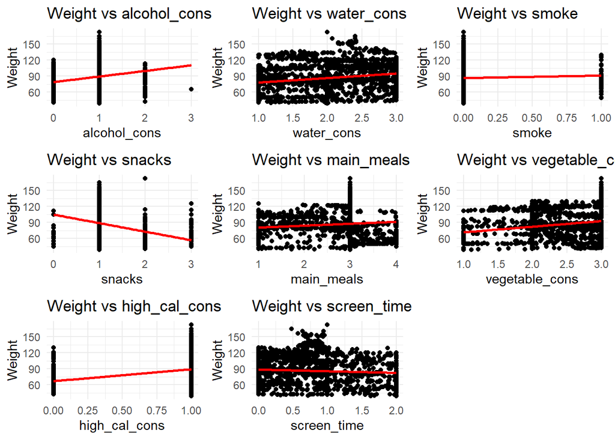

```r
correlation_matrix <- cor(h2_my_data ,
                          use = "complete.obs")
correlation_data <- melt(correlation_matrix)

heatmap_plot <- ggplot(correlation_data, aes(Var1, Var2, fill = value)) +
  geom_tile() +
  scale_fill_gradient2(low = "blue", high = "red", mid = "white",
                       midpoint = 0, limit = c(-1, 1)) +
  theme_minimal() +
  labs(title = "Correlation Heatmap Between Lifestyle Factors and Weight")

scatter_plots <- lapply(names(h2_my_data)[2:9], function(var) {
  ggplot(h2_my_data, aes_string(x = var, y = "weight")) +
    geom_point() +
    geom_smooth(method = "lm", se = FALSE, color = "red") +
    labs(title = paste("Weight vs", var), x = var, y = "Weight") +
    theme_minimal()
})
grid.arrange(heatmap_plot, grobs = scatter_plots, ncol = 3)
```

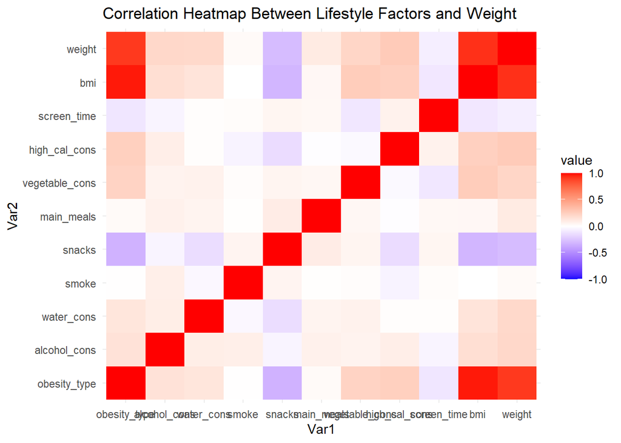

```r
heatmap_plot
```

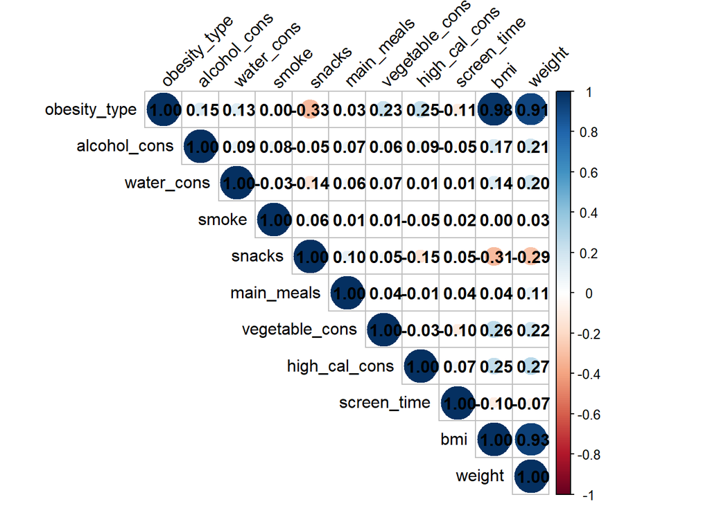

```r
corrplot(cor(h2_my_data, use = "complete.obs"),
  method = "circle",
  type = "upper",
  addCoef.col = "black",
  tl.col = "black",
  tl.srt = 45,
  diag = T
)
```

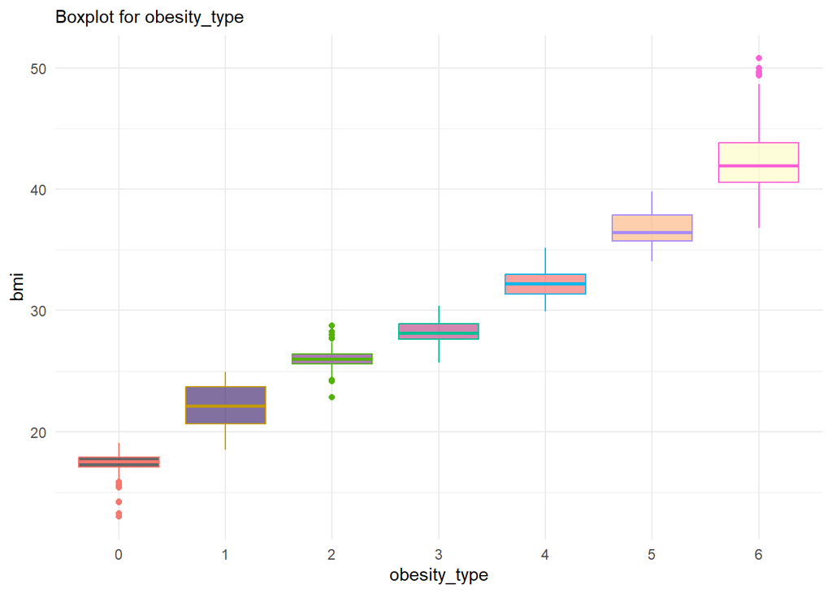

```r
create_boxplot <- function(data, category_col, num_col) {

  data[[category_col]] <- round(data[[category_col]])
  data[[category_col]] <- factor(data[[category_col]])

  plot <- ggplot(data, aes(x = .data[[category_col]], y = .data[[num_col]], fill = .data[[category_col]], colour = .data[[category_col]])) +
    geom_boxplot() +
    scale_fill_viridis(discrete = TRUE, alpha = 0.6, option = "A") +
    theme_minimal() +
    theme(
      legend.position = "none",
      plot.title = element_text(size = 11)
    ) +
    ggtitle(paste("Boxplot for", category_col)) +
    xlab(category_col) +
    ylab(num_col)

  return(plot)
}


create_boxplot(h2_my_data, "obesity_type", "bmi")
```

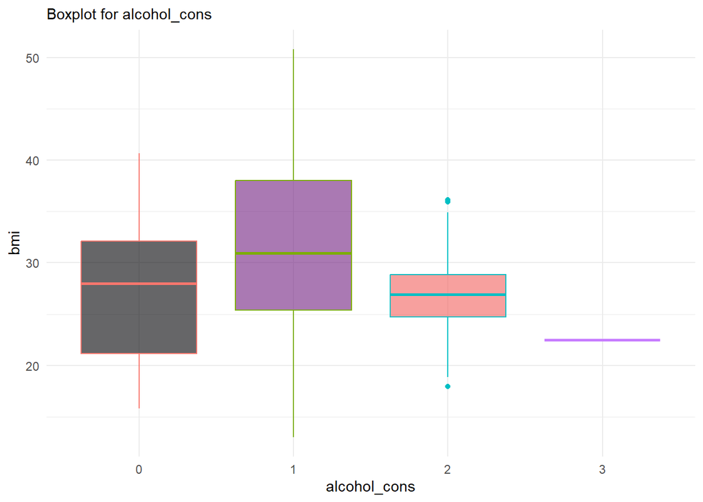

```r
create_boxplot(h2_my_data, "alcohol_cons", "bmi")
```

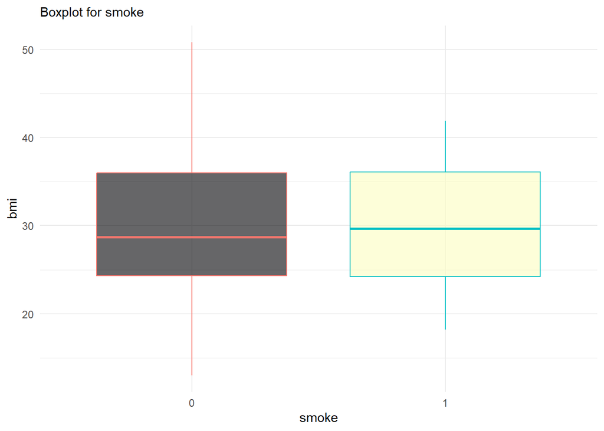

```r
create_boxplot(h2_my_data, "smoke", "bmi")
```

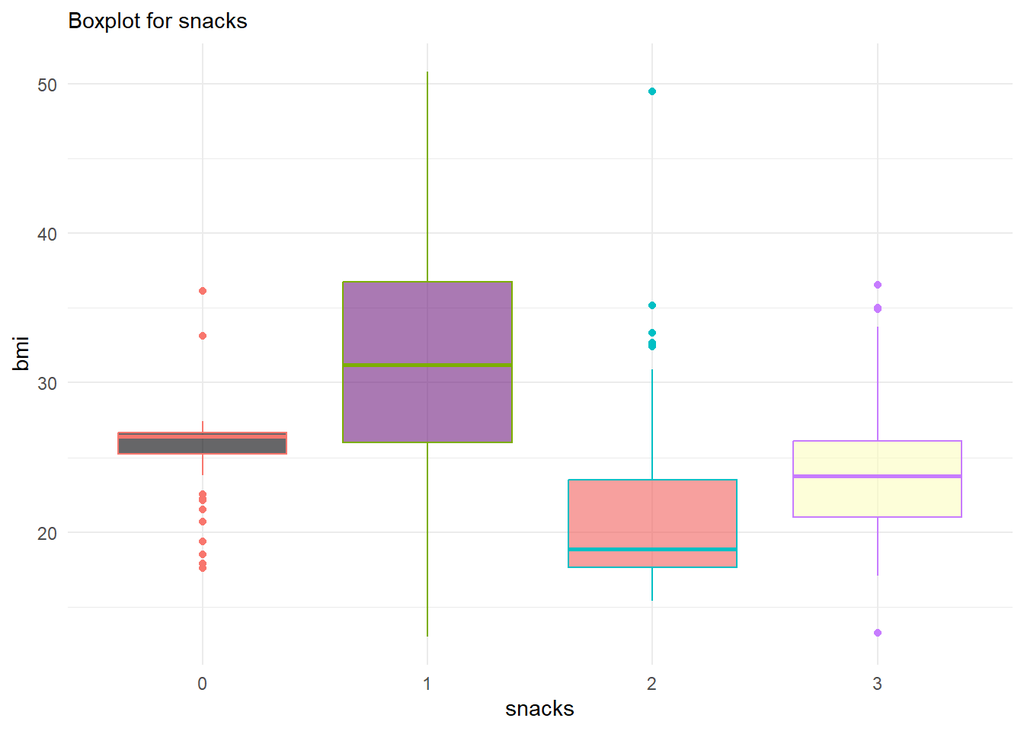

```r
create_boxplot(h2_my_data, "snacks", "bmi")
```

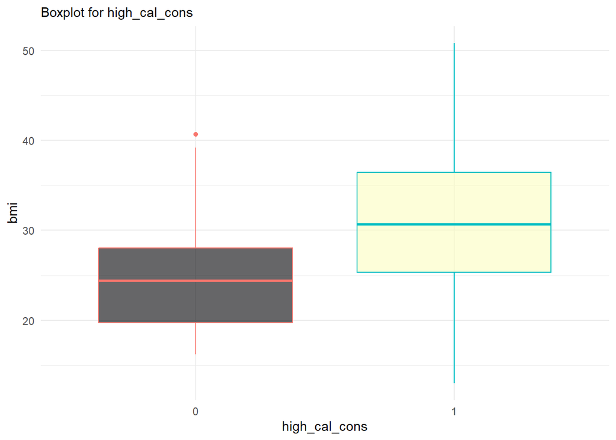

```r
create_boxplot(h2_my_data, "high_cal_cons", "bmi")
```

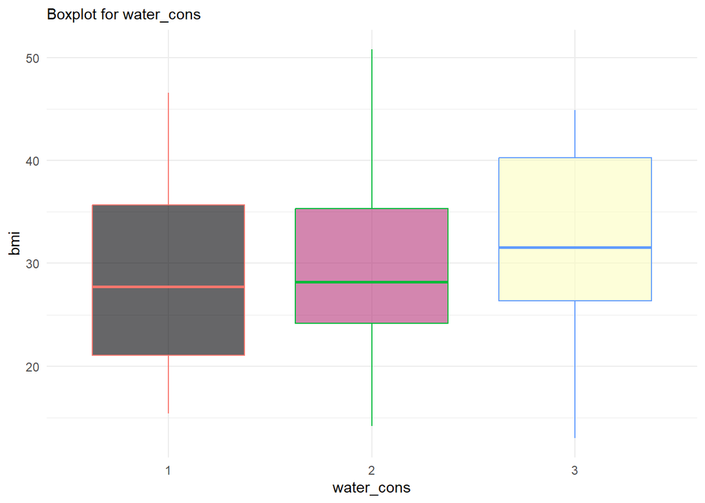

```r
create_boxplot(h2_my_data, "water_cons", "bmi")
```

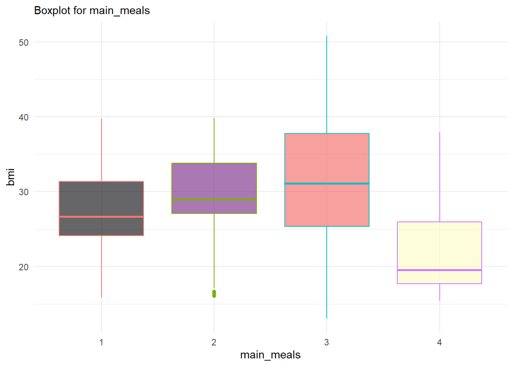

```r
create_boxplot(h2_my_data, "main_meals", "bmi")
```

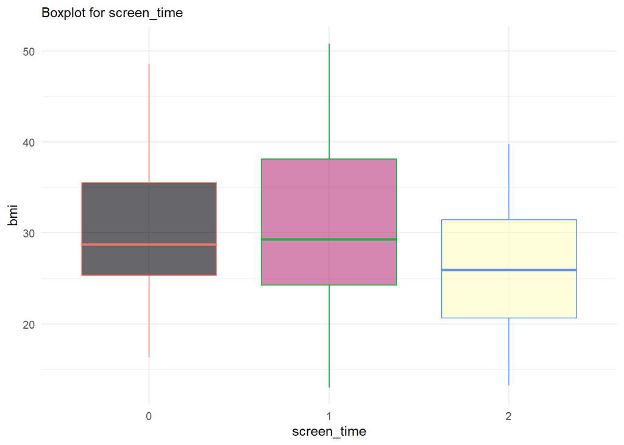

```r
create_boxplot(h2_my_data, "screen_time", "bmi")
```

```r
perform_stat_test <- function(data, category_col, num_col) {
  num_levels <- length(unique(data[[category_col]]))

  # Eğer kategori değişkeninin 2 seviyesi varsa Wilcoxon testi yapılır
  if (num_levels == 2) {
    test_result <- wilcox.test(data[[num_col]] ~ data[[category_col]], data = data)
    test_type <- "Wilcoxon Test"
  }
  # Eğer kategori değişkeninin 3 veya daha fazla seviyesi varsa Kruskal-Wallis testi yapılır
  else if (num_levels > 2) {
    test_result <- kruskal.test(data[[num_col]] ~ data[[category_col]], data = data)
    test_type <- "Kruskal-Wallis Test"
  }
  # Diğer durumlar için hata mesajı döndür
  else {
    return("Error: Kategorik değişkenin en az 2 seviyesi olmalıdır.")
  }

  # Test sonucunu döndür
  return(list(test_type = test_type, p_value = test_result$p.value, test_result = test_result))
}
```

```r
perform_stat_test(h2_my_data, "obesity_type", "bmi")
```

```
## $test_type
## [1] "Kruskal-Wallis Test"
##
## $p_value
## [1] 0
##
## $test_result
##
##  Kruskal-Wallis rank sum test
##
## data:  data[[num_col]] by data[[category_col]]
## Kruskal-Wallis chi-squared = 2059.8, df = 6, p-value < 2.2e-16
```

The p-value here is 2.2e-16, which is a very small value, which provides strong evidence to reject hypothesis H0. That is, there is a significant difference between different levels of the categorical variable in your dataset. In this case, we can say that there are significant differences in terms of medians between the groups.

```r
perform_stat_test(h2_my_data, "alcohol_cons", "bmi")
```

```
## $test_type
## [1] "Kruskal-Wallis Test"
##
## $p_value
## [1] 3.607986e-21
##
## $test_result
##
##  Kruskal-Wallis rank sum test
##
## data:  data[[num_col]] by data[[category_col]]
## Kruskal-Wallis chi-squared = 98.299, df = 3, p-value < 2.2e-16
```

```r
perform_stat_test(h2_my_data, "smoke", "bmi")
```

```
## $test_type
## [1] "Wilcoxon Test"
##
## $p_value
## [1] 0.9169886
##
## $test_result
##
##  Wilcoxon rank sum test with continuity correction
##
## data:  data[[num_col]] by data[[category_col]]
## W = 45057, p-value = 0.917
## alternative hypothesis: true location shift is not equal to 0
```

```r
perform_stat_test(h2_my_data, "snacks", "bmi")
```

```
## $test_type
## [1] "Kruskal-Wallis Test"
##
## $p_value
## [1] 1.790187e-88
##
## $test_result
##
##  Kruskal-Wallis rank sum test
##
## data:  data[[num_col]] by data[[category_col]]
## Kruskal-Wallis chi-squared = 409.66, df = 3, p-value < 2.2e-16
```

```r
perform_stat_test(h2_my_data, "high_cal_cons", "bmi")
```

```
## $test_type
## [1] "Wilcoxon Test"
##
## $p_value
## [1] 2.408424e-30
##
## $test_result
##
##  Wilcoxon rank sum test with continuity correction
##
## data:  data[[num_col]] by data[[category_col]]
## W = 125896, p-value < 2.2e-16
## alternative hypothesis: true location shift is not equal to 0
```

```r
perform_stat_test(h2_my_data, "water_cons", "bmi")
```

```
## $test_type
## [1] "Kruskal-Wallis Test"
##
## $p_value
## [1] 3.527896e-10
##
## $test_result
##
##  Kruskal-Wallis rank sum test
##
## data:  data[[num_col]] by data[[category_col]]
## Kruskal-Wallis chi-squared = 1602.4, df = 1267, p-value = 3.528e-10
```

```r
perform_stat_test(h2_my_data, "main_meals", "bmi")
```

```
## $test_type
## [1] "Kruskal-Wallis Test"
##
## $p_value
## [1] 0.07830997
##
## $test_result
##
##  Kruskal-Wallis rank sum test
##
## data:  data[[num_col]] by data[[category_col]]
## Kruskal-Wallis chi-squared = 685.09, df = 634, p-value = 0.07831
```

```r
perform_stat_test(h2_my_data, "screen_time", "bmi")
```

```
## $test_type
## [1] "Kruskal-Wallis Test"
##
## $p_value
## [1] 3.145026e-13
##
## $test_result
##
##  Kruskal-Wallis rank sum test
##
## data:  data[[num_col]] by data[[category_col]]
## Kruskal-Wallis chi-squared = 1504.3, df = 1128, p-value = 3.145e-13
```